# IODS course diary

## 5. Regression diagnostics

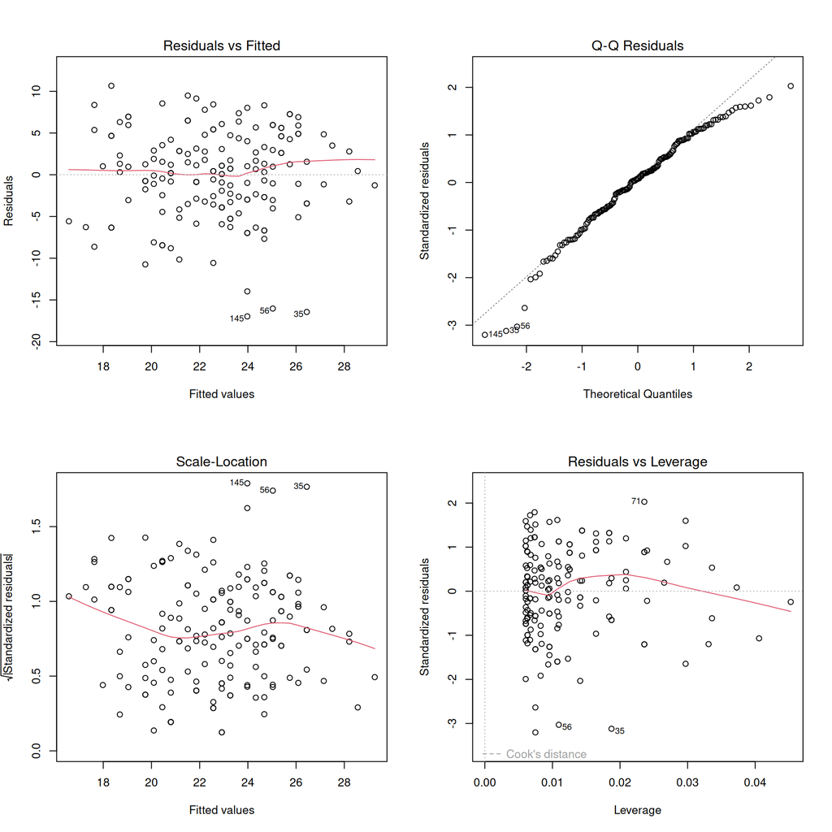

2.0 Regression diagnostics

```r
par(mfrow=c(2,2))
plot(attitude_model)
```

```r
par(mfrow=c(1,1))
```

### 5.1 Assumptions

The assumptions of the model are that: 1. the constant variance assumption (homoscedasticity) 2. the normality assumption: 3. there’s a linear relationship between the predictor and the response

#### The Residuals vs. Leverage

The Residuals vs. Leverage plot checks that there aren’t any influential outliers that are affecting the fit of the regression coefficients. The plot has a dashed line showing a critical Cooks’s distance value. In our case this dashed line is not visible. Essentially, if a point is very far right and has a high standardized residual (off the central line), it’s an higly influential point and will have to be looked into.

A highly influential point may be an indication of a point that should be excluded, but this has to be done on a case-by-case basis. It might also mean that assumption 3 is violated, that there isn’t a linear relationship between predictors and the response.

#### The Residuals vs. Fitted plot

The residuals vs fitted plot (and the scale-location plot) gives us a visual way to check for heteroscedasticity (violation of assumption 1). If the red mean-line is not horizontal, it means the residuals have a bias in some region of the response distribution (the vairance is not constant).

I don’t think this means the data is heteroscedastic, it certainly doesn’t look like it is. But I’m not so familiar with these visual checks, so I searched the web for a homoscedasticity test, and found the *Breusch-Pagan Test* in the `lmtest` library.

```r
attitude_model_bptest <- bptest(attitude_model)
attitude_model_bptest
```

```
##
##  studentized Breusch-Pagan test
##
## data:  attitude_model
## BP = 0.0039163, df = 1, p-value = 0.9501
```

A p-value of `0.95` means that there is definitely very little evidence that the model is heteroscedastic. Ok, good! The trend has to be much clearer than that then.

#### Normal QQ-plot

This plot compares the “ideal” quantiles to the sample quantiles. This is used to test for normalcy by comparing the residual distribution against a theoretical normal distribution.

There are some outliers at the bottom left, which may indicate a bimodal distribution (remember that the exam scores looked bimodal as well, fig 1.4). The plot also curves down a little at the upper end, which I believe usually indicates a light left skew.

let’s test the residuals for normalcy, using the Shapiro-Wilk test:

```r
shapiro.test(attitude_model[["residuals"]])
```

```
##
##  Shapiro-Wilk normality test
##
## data:  attitude_model[["residuals"]]
## W = 0.97394, p-value = 0.003195
```

The p-value is quite small, 0.003, so we to reject the null hypothesis that the residuals are normally distributed.

Hmm, maybe the issue is the grading scale? I’ve tried to fix this, and I can ge the QQ-plot to look nicer with some transformations, but it makes the model test statistics worse. This is the best I can do for now.

# Assignment 3: Logistic regression

## 1. Get the data

```r
library(dplyr)
library(readr)
data_url <- "https://raw.githubusercontent.com/KimmoVehkalahti/Helsinki-Open-Data-Science/master/datasets/alc.csv"
df <- read_csv(data_url)
```

## 2. Summary of variables

The variables in the data set are:

```r
colnames(df)
```

```
##  [1] "school"     "sex"        "age"        "address"    "famsize"
##  [6] "Pstatus"    "Medu"       "Fedu"       "Mjob"       "Fjob"
## [11] "reason"     "guardian"   "traveltime" "studytime"  "schoolsup"
## [16] "famsup"     "activities" "nursery"    "higher"     "internet"
## [21] "romantic"   "famrel"     "freetime"   "goout"      "Dalc"
## [26] "Walc"       "health"     "failures"   "paid"       "absences"
## [31] "G1"         "G2"         "G3"         "alc_use"    "high_use"
```

The dataset contains student school performance data averaged over two courses: portuguese and mathematics (the variables are: G1, G2, G3, absences, failures, paid). To be exact, the “paid” column is only from one of the courses. The other variables are demographic and social, the social variables were collected using surveys.

Two variables: alc_use and high_use are transformations of the original dataset added for this assignment. alc_use is the average alcohol use per day, combining self-reported weekday and weekend usage on a scale of 1 to 5. high_use is a boolean indicating whether the alc_use variable is more than 2.

## 3. Choose 4 interesting variables in the data to study in relation to alcohol use

I choose:

- Fedu: Father’s education level
- Medu: Mother’s education level
- absences: number of absences on average per course
- G3: final course grade average

My hypotheses is:

- parents education levels (Fedu,Medu) has a small but significant impact on the likelihood of the high_use variable.
- increase in absences incrreases likelihood of high alcohol usage
- decrease in grades increases likelihood of high alcohol usage

## 4. Explore variables

[output not shown]

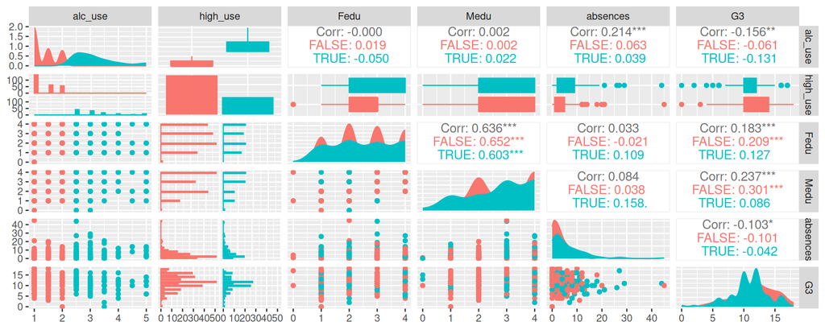

fig. 1.1, correlation matrix of variables, colored by high_use value

```r
library(ggplot2)
library(GGally)
df %>% select(alc_use, high_use, Fedu, Medu, absences, G3) %>%
  ggpairs(aes(fill=high_use, color=high_use))
```

Two out of four hypotheses seem to have some support in the data after this exploration.

## 5. Logistic regression

Let’s do a logistic regression model using the two statistically significant correlations: G3 and absences.

```r
model <- glm(high_use ~ G3 + absences, data = df, family = "binomial")
summary(model)
```

```
##
## Call:
## glm(formula = high_use ~ G3 + absences, family = "binomial",
##     data = df)
##
## Coefficients:
##             Estimate Std. Error z value Pr(>|z|)
## (Intercept) -0.38732    0.43500  -0.890 0.373259
## G3          -0.07606    0.03553  -2.141 0.032311 *
## absences     0.08423    0.02309   3.648 0.000264 ***
## ---
## Signif. codes:  0 '***' 0.001 '**' 0.01 '*' 0.05 '.' 0.1 ' ' 1
##
## (Dispersion parameter for binomial family taken to be 1)
##
##     Null deviance: 452.04  on 369  degrees of freedom
## Residual deviance: 429.93  on 367  degrees of freedom
## AIC: 435.93
##
## Number of Fisher Scoring iterations: 4
```

Both G3 and absences have a p-value of less than 0.5 for the Wald tests of the fit, but we have a better test that’s easier to interpret, the confidence intervals from the model.

### 5.1 Odds ratio

```r
coeffs <- coefficients(model)
odds_ratio <- coeffs %>% exp
odds_ratio
```

```
## (Intercept)          G3    absences
##   0.6788751   0.9267616   1.0878762
```

The odds ratios for G3 and absences are roughly 0.926 and 1.088 For G3, the OR is less than one because the correlation between the variables is negative.

The way to interpret these is that: - for each decrease in final grade average, the odds increase by roughly 8.0% that a student has high alcohol use (1/0.9267 ~= 1.08) - for each increase in absences per course, the odds increase by roughly 8.7% that a student has high alcohol use

But that’s just the average effect the model has fit, let’s look at confidence intervals in the odds ratio

### 5.2 Confidence intervals

```r
ci <- confint(model) %>% exp
ci
```

```
##                 2.5 %    97.5 %
## (Intercept) 0.2857593 1.5832545
## G3          0.8639686 0.9935498
## absences    1.0419618 1.1407755
```

The 95% confidence intervals are both on one side of unity, so we can say with 95% certainty that there is an effect for both variables, and the effect increases the odds by: - a factor in the range of [1.007, 1.15] for each decrease in final grade average (again,inverting the odds ratio because the effect is negative) - a factor in the range of [1.04, 1.14] for each increase in absences per course

### 5.3 Interpretation

There is an effect, although the final grade average effect goes damn near 1 at the low end of the confidence interval, the unit increase in odds is only 0.7%! For absences, the confidence interval is a little tighter, but it still seems a little wide to me for practical use. We would need more samples in order to get a tighter interval.

The two hypotheses that survived the initial exploration both match the outcomes of the logistic regression, and now we can quantify the quality of an estimate of the effect.

## 6. Predictions

Let’s test out the model with a confusion matrix.

```r
probabilities <- predict(model, type = "response")
df <- df %>%
        mutate(probability = probabilities) %>%
        mutate(prediction = probability > 0.5)

table(high_use = df$high_use, prediction = df$prediction) %>%
        prop.table %>%
        addmargins
```

```
##         prediction
## high_use      FALSE       TRUE        Sum
##    FALSE 0.68108108 0.01891892 0.70000000
##    TRUE  0.25675676 0.04324324 0.30000000
##    Sum   0.93783784 0.06216216 1.00000000
```

The confusion matrix tells us that the model has a false positive rate of ~2% and a false negative rate of ~26%. That’s pretty good! High false negative rates are not so bad, they are just missed cases. High false positives would mean that the model is unreliable and cannot be used as an indicator (in *this* case. The importance of different error types depend on the specific use case and the meaning of negative and positive).

On the other hand, the confusion matrix also tells us that the model preficts 94% of all students to have non-high alcohol use, while in reality the number is 70%. So the model achieves this relative safe indicator status by being rather conservative.

### Caveat

We haven’t done a split into a model fit dataset and a validation set, so this confusion matrix is of limited value.